# Existen montañas de evidencia

Hace varios años ya conocí a esta persona y congeneamos de inmediato. Era "livianita de sangre" como decía mi mamá, entonces las risas y la naturaleza nos unía. Porque claro, nos conocimos recorriendo el parque nacional Laguna de Laja, en las faldas del Volcán Antuco.

Eramos dos mentes buscando respuestas en la naturaleza, compartiendo dudas y relatos de todo tipo mientras llenávamos las botellas de agua desde los frios esteros provocados por los días de verano. Filo la cosa es que dadas las coincidencias de la vida y luego de varios años volvímos a encontrarnos, pero ahora en la bohemia de Valparaíso.

Fue la interacción de la alegría genuina de volver a hablar con alguien, ¿me entiendes? hablamos de nuevas aventuras, sobre desiciones de vida y bla bla bla. Todo hasta que afirmó que no existía evidencia alguna de que la tierra fuera esférica, que por supuesto todo apuntaba a que la tierra era plana, por supuesto.

Hasta ese momento (2016) yo pensaba que los terraplanistas eran un meme de internet, entonces podrán comprender que casi escupo mi cerveza al oir tamaña afirmación jajaj. Acto seguido, yo trataba de explicar las razones por las que podemos deducir la forma de la tierra y no no no, la perspectiva, no hay evidencia. Entonces el lazo se rompió por esta realidad irreconciliable de ser un cordero domesticado por el sistema.

Este caso me hace pensar que en realidad no existe evidencia suficiente para alguien, si es que es abstracta, si no es percibida directamente por los sentidos. Entonces, hay que hacer algunos esfuerzos para poder crear observaciones comprobables por esta vía. ¿Cómo podría yo convencer a alguien que no escucha razones? Que sus ojos vean directamente la evidencia, que estoy seguro que lo ha hecho. Los protagonistas serán dos montañas que son visibles desde Valparaíso: El cerro La Campana y el Cerro Aconcagua, la montaña más alta de la Cordillera de los Andes.

[figure not shown]

Mucha gente no sabe que desde el famoso mirador 21 de Mayo es posible ver territorio Argentino, incluso hay una fase de negación: ¿Cómo siquiera es posible que podamos ver la cordillera desde la costa? ¿Tan gigante es la cordillera? ¿Tan estrecho es Chile? Chile hace gala es de su completa falta del Oeste y el Este, y por resultado, Chile está lejos de Chile.

Incluso, hay registros de un fotógrafo llamado Roberto Antezana que fue "funado" (por decirlo de alguna forma) por publicar exactamente la misma foto que muestro arriba. Lo molestaron por hacer una foto sobre la realidad, y la realidad incomoda cuando no es acorde a lo que crees, supongo.

https://www.latercera.com/paula/el-fotografo-de-lo-imposible/

Pero volvamos al Aconcagua, al Cerro La Campana y a la foto en cuestión. Es una gran coincidencia que dos montañas tan diferentes estés *casi casi* a la misma altura, ¿no?. En el plano del abstracto, yo podría mover el cerro la Campana y pareciera que tiene más o menos el mismo porte. De hecho, es extremadamente posible existe algún lugar en la V región donde el Aconcagua no es visible porque La Campana lo *eclipsa*. Brigido.

Por su puesto que es una concidencia, y la utilizaremos para tratar de inferir una verdad implicita a nuestro alrededor. Hoy trataré de demostrarles que la tierra no es plana usando una coincidencia geológica.

## La foto y las suposiciónes

La base de esta idea es simplificar lo más posible todos los aspectos para que la conclusión esté a la vista. Trataremos de ser rigurosos dentro de la simplicidad de los argumentos; y cualquier cosa que resulte interesante o problemática será mencionada.

Sobre la foto: fue hecha en un día extremadamete despejado de Mayo del 2020 desde el famoso Mirador 21 De Mayo, en el Cerro Playa Ancha (Aguante); éste será el origen desde donde situaremos nuestro punto de vista. Fue tomada con un teleobjetivo de 300mm de distancia focal y luz de medio día.

Basados en la foto, mostraremos que sus alturas son comparables desde el lugar que la foto fue obtenida, y usando las propiedades físicas de las montañas (en este caso la distancia y la altura) en una geometría plana, para así demostrar que no encaja. Luego, comprobaremos que al considerar la tierra esférica todo se soluciona.

Los datos fueron tomados desde internet en bases de datos libres. Tomaremos las alturas de cada uno desde Wikipedia, y las distancias desde google earth. Ésto último puede ya ser un problema de por si, porque me imagino que la distancias han sido corregidas por la curvatura de la tierra, por ende aplicar estas mediciones en una geometría diferente introducirá incerteza a las estimaciones. No importa, estoy dispuesto a correr el riesgo.

Ahora, ¿cómo sabemos que son esas las montañas de las que hablamos? Considerando las imágenes de las cumbres de cada montaña, y considerando que nuestro punto de vista es desde la izquierda, podemos ver que el perfil corresponde al de la foto que hice en el 2020 :D

| Cerro La Campana: 1.880 Metros de altura | Cerro Aconcagua: 6.961 metros de altura. |
| --- | --- |

### La selección del horizonte

Lo primero será dibujar una linea recta horizontal entre ambas cumbres, para tener una idea de lo que me refería a mover la campana y eclipsar. Obviamente existe una linea horizontal a la imágen que pasa muy cerca de ambas cumbres. En la imagen, en realidad hemos considerados dos lineas horizontales: la de las cumbres, y otra que ha sido alineadas con las lineas de horizontales de los edificios que han sido levantados en Viña del Mar. Esta línea ha sido elegida usando esto en consideración, y luego otra linea, con la misma pendiente ha sido dibujada.

[figure not shown]

Si somos observadores, podemos ver de hecho que la cumbre de La Campana sobresale un poco a la linea trazada, mientras que la cumbre del Aconcagua lo cobre perfectamente. Entonces, podemos decir que, desde nuestra perspectiva, el cerro La Campana es incluso más alto que la que es considerada la mayor mole de piedra de sudamérica.

¿Tiene esto sentido en la tierra plana? Por su puesto, por la ya gran citada y gloriosa perspectiva, con la cual fundamentan todos y cada uno de sus argumentos. Por supuesto que es posible que se vea más alta si estamos suficientemente cerca de la montaña. La campana está en Olmué, obviamente los Olmueínos ni por suerte verán el Aconcagua, sólo por mencionar lo obvio. Entonces el siguiente paso es averiguar a cuánta distancia está cada una de esas montañas desde donde hicimos la foto: el Mirador 21 de Mayo.

Usando Google earth, estimamos que La Campana está a respetables 48,47 Km, mientras que el Aconcagua dista más de 157 Km.

| Distancia hasta el cerro La Campana: 48,47 Km | Distancia hasta el cerro Aconcagua: 157.08 Km |
| --- | --- |

Dados toda esta información, haremos algo muy, muy simple: Pondremos esta información en un plano cartesiano (o sea, considerando que la tierra es plana) y dibujaremos una linea de visión hasta dónde dista cada una de cumbres de las montañas elegidas.

Asumido el modelo de la tierra plana, éste se confirmaría si es que ambas líneas de visión coinciden. Entonces, para la campana asumimos que tiene una altura de 1880 metros, y está a 48,47 Km de distancia, y que el Aconcagua tiene una altura de 6961 metros (csm) y una distancia de 157.08 Km.

Ambas lineas de visión (la linea desde el origen a la cumbre) deberían coincidir.

¡NO SE DIGA MÁS!

| Montaña | Distancia | Altura |
| --- | --- | --- |
| La Campana | 48.5 [Km] | 1880 [m] |
| Aconcagua | 157.08 [Km] | 6961 [m] |

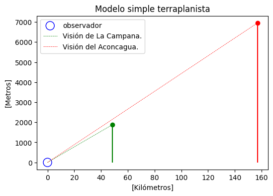

```python
import matplotlib.pyplot as plt
plt.figure(figsize=(6,4))

LaCampana = [48.47, 1880]
Aconcagua = [157.08, 6961]

#Observador

plt.scatter(0, 0, s=150, facecolors='none', edgecolors='b', label='observador')
plt.plot(LaCampana[0],LaCampana[1], 'og' )
plt.plot([0,LaCampana[0]],[0,LaCampana[1]], '--g', lw=0.5, label='Visión de La Campana.')
plt.vlines(x=LaCampana[0], ymin=0, ymax=LaCampana[1], color='green')

plt.plot(Aconcagua[0],Aconcagua[1], 'or' )
plt.plot([0,Aconcagua[0]],[0,Aconcagua[1]], '--r', lw=0.5, label='Visión del Aconcagua.')
plt.vlines(x=Aconcagua[0], ymin=0, ymax=Aconcagua[1], color='r')

plt.title("Modelo simple terraplanista")
plt.ylabel("[Metros]")
plt.xlabel("[Kilómetros]")

plt.legend(loc='best')
plt.show()
```

El observador, demarcado con un círculo azul, está en Valparaíso, y prácticamente a la altura del mar, lo que define el origen (x,y)=(0,0) de la gráfica. Desde ahí, se desprende una linea hasta la cumbre de cada montaña: un punto verde para la Campana, y el punto rojo para el Aconcagua.

Las lineas puntuadas hacia cada cumbre no coninciden como esperaríamos dada la primera imagen, sino que el modelo sugiere que el Aconcagua sería un poco más alto de lo que se observa.

Las lineas deberían coincidir y no lo hacen. Esta diferencia es muy pequeña, pero medible. Aquí todo se reduce a trigonometría de triángulos rectángulos como el que sigue:

[figure not shown]

Entonces, cuánto vale la diferencia entre la cima de la campana a la linea de visión del aconcagua? En otras palabras, cuánto vale $x$?

Primero los triángulos grandes, si llamamos $A = x + h_c$, entonces podemos usar propiedades trigonométricas para evaluar los lados, como por ejemplo que $H^2 = dc^2 + A^2$, o además usando las relaciones de coseno tenemos que:

$$Cos(\alpha) = \dfrac{\mbox{Cateto adyacente}}{\mbox{hipotenusa}} = \dfrac{da}{Hip} = \dfrac{dc}{H}, $$

De aquí tenemos que:

$$H = \dfrac{dc\times Hip}{da}$$

,

También, tenemos que por las relaciones de Seno se cumple que:

$$Sen(\alpha) = \dfrac{\mbox{Cateto opuesto}}{\mbox{hipotenusa}} = \dfrac{ha}{Hip} = \dfrac{A}{H}, $$

Así:

\begin{align*} A &= \dfrac{ha \times H}{Hip},\ \ \ \ \mbox{reemplazamos $H$} \\ &= \dfrac{ ha \times dc \times Hip}{Hip\times da},\\ &= \dfrac{dc \times ha}{da} \\ \end{align*}

Y como $A = x + h_c$, tenemos que:

\begin{align*} x + h_c &= \dfrac{dc \times ha}{da} \\ x &= \dfrac{dc \times ha}{da} - hc,\\ \end{align*}

```python
#Cantidades en metros:
dc, hc, da, ha = 48470, 1880, 157080, 6961

x = dc*ha/da - hc

print("A la campana le faltan %0.2f [metros] para alcanzar la linea de visión del Aconcagua" %x)
```

```
A la campana le faltan 267.95 [metros] para alcanzar la linea de visión del Aconcagua
```

Entonces, tenemos que la distancia $x$ es 267.95 [m]

Por otro lado, podemos medir la cantidad demarcada con un símbolo ? de la siguente forma: como $ha = D+ ?$

$$tan(\alpha) = \dfrac{\mbox{Cateto opuesto}}{\mbox{cateto adyasente}} = \dfrac{hc}{dc} = \dfrac{D}{da}, $$\begin{align*} D &= \dfrac{da \times hc}{dc} \\ ha - ? &= \dfrac{da \times hc}{dc} \\ ? &= ha - \dfrac{da \times hc}{dc} \end{align*}

```python
print(ha-da*hc/dc)
```

```
868.3571281204868
```

\begin{align*} ? &= 868.35 \mbox{ m} \end{align*}

## Modelo de profundidad

[figure not shown]

Para el cerro la campana también hay una profundidad calculable pero también la ignoraremos en primera instancia. La idea es calcular el largo de la linea azul.

Como las alturas están hechas desde el cero, tenemos que $ha = D + x$, donde $D$ es la parte del Aconcagua que logramos ver por sobre el horizonte y $x$ la parte que se hunde.

como tenemos que $$tan(\Omega) = \dfrac{\mbox{Cateto opuesto}}{\mbox{cateto adyasente}} = \dfrac{hc}{dc} = \dfrac{D}{da}, $$

\begin{align*} D &= \dfrac{da \times hc}{dc} \\ ha - x &= \dfrac{da \times hc}{dc} \\ x &= ha - \dfrac{da \times hc}{dc} \\ x &= 868.3571 \mbox{ m} \end{align*}

El que, por supuesto, es el mismo valor calculado anteriormente. De alguna forma, hicimos que los puntos de vista se alinearan enterrando el Aconcagua 868.3571 m. Y funciona:

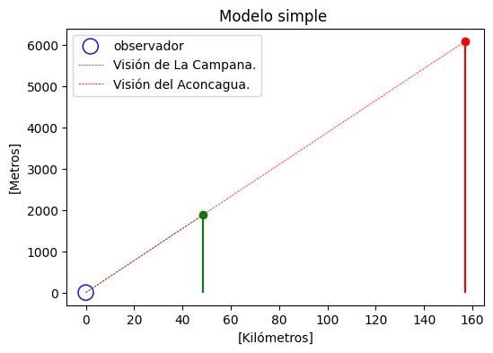

```python
import matplotlib.pyplot as plt
plt.figure(figsize=(6,4))

LaCampana = [48.47, 1880]
Aconcagua = [157.08, 6961]

dc, hc, da, ha = 48470, 1880, 157080, 6961

correccion = ha-(da*hc/dc)

#Observador
plt.scatter(0, 0, s=150, facecolors='none', edgecolors='b', label='observador')
plt.plot(LaCampana[0],LaCampana[1], 'og' )
plt.plot([0,LaCampana[0]],[0,LaCampana[1]], '--g', lw=0.5, label='Visión de La Campana.')
plt.vlines(x=LaCampana[0], ymin=0, ymax=LaCampana[1], color='green')

plt.plot(Aconcagua[0],Aconcagua[1]-correccion, 'or' )
plt.plot([0,Aconcagua[0]],[0,Aconcagua[1]-correccion], '--r', lw=0.5, label='Visión del Aconcagua.')
plt.vlines(x=Aconcagua[0], ymin=0, ymax=Aconcagua[1]-correccion, color='r')

plt.title("Modelo simple ")
plt.ylabel("[Metros]")
plt.xlabel("[Kilómetros]")

plt.legend(loc='best')
plt.show()
```

Pero, si la corrección es de más de 800 metros. Podemos obtener la curvatura de la tierra?

$$ curvatura = \dfrac{868.35\mbox{ m}}{157.08 \mbox{ km} } = 5.52 \dfrac{\mbox{ m}}{\mbox{ km} } $$